# Extended evaluation of differential chromatin interaction detection analysis using real Hi-C data

John Stansfield, Mikhail Dozmorov

# Introduction

To evaluate the performance of different normalization methods on the detection of chromatin interaction differences, controlled changes were used. Real Hi-C data is used: GM12878, Chromosome 1, MboI vs. DpnII restriction enzymes, 1Mb resolution. The dimensions of the chromatin interaction matrices are 250 x 250. The performance of the joint (`loess`) and individual (`ChromoR`, Iterative Correction and Eigenvector decomposition - `ICE`, Knight-Ruiz - `KR`, Sequential Component Normalization - `SCN`) normalization methods at varying fold changes (1.5 by default) and varying number of controlled changes (500 by default) is investigated. The data were globally rescaled to have the same total count of interaction frequencies.

Fold changes are applied to one of the datasets by upregulating the selected IF if the difference between the datasets is positive. If the difference between the datasets at that point is negative the IF is downregulated by the specified fold change. This method of making changes ensures that the fold change specified is actually realized on the MD plot.

## The effect of fold change

### 1.5 Fold change

|  | loess | chromoR | ice | kr | scn |
| --- | --- | --- | --- | --- | --- |
| true positive | 211 | 14 | 11 | 13 | 7 |
| false positive | 1000 | 1440 | 1150 | 1200 | 1200 |
| true negative | 24900 | 29400 | 23800 | 24700 | 24700 |
| false negative | 289 | 486 | 467 | 487 | 493 |
| Total | 26400 | 31400 | 25400 | 26400 | 26400 |
| TPR | 0.422 | 0.028 | 0.023 | 0.026 | 0.014 |
| SPC | 0.961 | 0.953 | 0.954 | 0.954 | 0.954 |
| F1 | 0.975 | 0.968 | 0.967 | 0.967 | 0.967 |
| AUC | 0.855 | 0.541 | 0.766 | 0.752 | 0.701 |
| AUC 20% | 0.115 | 0.0216 | 0.0786 | 0.0761 | 0.057 |

[output cut: 7 more lines]

### 2.0 Fold change

|  | loess | chromoR | ice | kr | scn |
| --- | --- | --- | --- | --- | --- |
| true positive | 369 | 9 | 39 | 42 | 50 |
| false positive | 856 | 1450 | 1130 | 1180 | 1160 |
| true negative | 25000 | 29400 | 23800 | 24700 | 24700 |
| false negative | 131 | 491 | 440 | 458 | 450 |
| Total | 26400 | 31400 | 25400 | 26400 | 26400 |
| TPR | 0.738 | 0.018 | 0.0814 | 0.084 | 0.1 |
| SPC | 0.967 | 0.953 | 0.955 | 0.954 | 0.955 |
| F1 | 0.981 | 0.968 | 0.968 | 0.968 | 0.968 |
| AUC | 0.963 | 0.582 | 0.57 | 0.576 | 0.598 |
| AUC 20% | 0.169 | 0.0256 | 0.0317 | 0.0329 | 0.0355 |

[output cut: 7 more lines]

### 4.0 Fold change

|  | loess | chromoR | ice | kr | scn |
| --- | --- | --- | --- | --- | --- |
| true positive | 477 | 82 | 386 | 397 | 340 |
| false positive | 735 | 1380 | 792 | 827 | 867 |
| true negative | 25200 | 29500 | 24200 | 25100 | 25000 |
| false negative | 23 | 418 | 93 | 103 | 160 |
| Total | 26400 | 31400 | 25400 | 26400 | 26400 |
| TPR | 0.954 | 0.164 | 0.806 | 0.794 | 0.68 |
| SPC | 0.972 | 0.955 | 0.968 | 0.968 | 0.967 |
| F1 | 0.985 | 0.971 | 0.982 | 0.982 | 0.98 |
| AUC | 0.992 | 0.508 | 0.972 | 0.966 | 0.95 |
| AUC 20% | 0.192 | 0.0211 | 0.177 | 0.173 | 0.163 |

[output cut: 7 more lines]

### 10.0 fold change

|  | loess | chromoR | ice | kr | scn |
| --- | --- | --- | --- | --- | --- |
| true positive | 492 | 364 | 471 | 490 | 480 |
| false positive | 726 | 1090 | 698 | 730 | 728 |
| true negative | 25200 | 29800 | 24200 | 25200 | 25200 |
| false negative | 8 | 136 | 10 | 10 | 20 |
| Total | 26400 | 31400 | 25400 | 26400 | 26400 |
| TPR | 0.984 | 0.728 | 0.979 | 0.98 | 0.96 |
| SPC | 0.972 | 0.965 | 0.972 | 0.972 | 0.972 |
| F1 | 0.986 | 0.98 | 0.986 | 0.986 | 0.985 |
| AUC | 0.995 | 0.864 | 0.994 | 0.994 | 0.987 |
| AUC 20% | 0.195 | 0.148 | 0.195 | 0.195 | 0.189 |

[output cut: 7 more lines]

### Bar plots

The bar plots show comparisons of the effect of different fold changes using fixed numbers of controlled changes on different performance metrics.

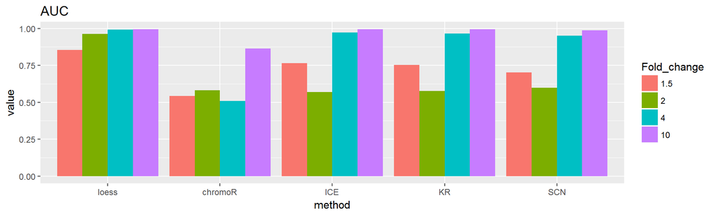

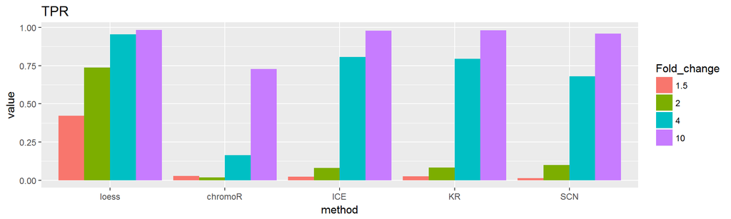

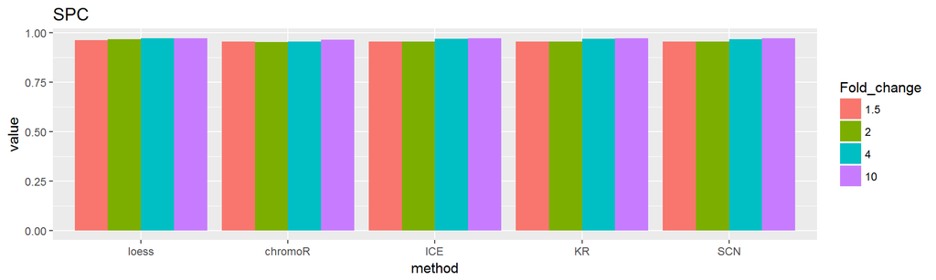

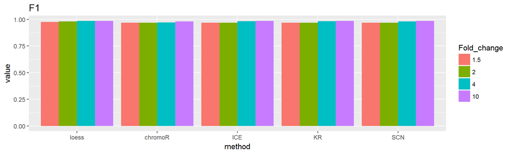

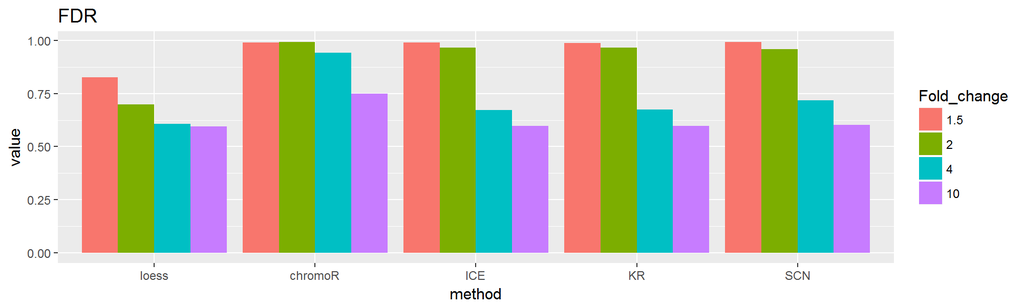

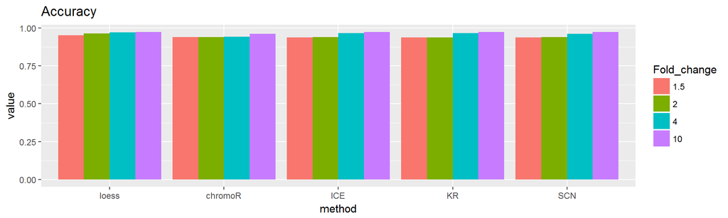

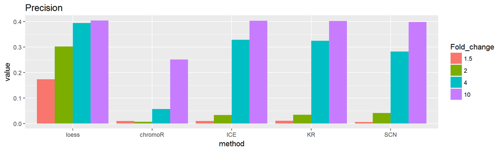

### Summary

For the real data with changes added, `loess` was once again able to detect the most true changes compared to the other normalization methods. `loess` was clearly superior at the lower fold changes (1.5 and 2) with much higher TPRs compared to the other methods with TPRs below 10%. `loess` also had the lowest number of false negtives compared to the other methods. The gap in detection once again began to close at the higher fold changes between `loess`, `KR`, `SCN`, and `ICE` however `loess` still was slightly better. `ChromoR` once again proved to be the worst normalization method and had the lowest detection rates.

## The effect of introduced number of changes

A given number of interaction frequencies were increased or decreased to produce a 1.5-fold change.

### 1 change

|  | loess | chromoR | ice | kr | scn |
| --- | --- | --- | --- | --- | --- |
| true positive | 1 | 0 | 0 | 0 | 0 |
| false positive | 1200 | 1460 | 1180 | 1220 | 1220 |
| true negative | 25200 | 29900 | 24200 | 25200 | 25200 |
| false negative | 0 | 1 | 1 | 1 | 1 |
| Total | 26400 | 31400 | 25400 | 26400 | 26400 |
| TPR | 1 | 0 | 0 | 0 | 0 |
| SPC | 0.955 | 0.953 | 0.954 | 0.954 | 0.954 |
| F1 | 0.977 | 0.976 | 0.976 | 0.976 | 0.976 |
| AUC | 0.981 | 0.54 | 0.996 | 0.996 | 0.77 |
| AUC 20% | 0.181 | 0 | 0.196 | 0.196 | 0 |

[output cut: 7 more lines]

### 100 changes

|  | loess | chromoR | ice | kr | scn |
| --- | --- | --- | --- | --- | --- |
| true positive | 51 | 3 | 4 | 4 | 4 |
| false positive | 1170 | 1460 | 1160 | 1220 | 1210 |
| true negative | 25100 | 29800 | 24200 | 25100 | 25100 |
| false negative | 49 | 97 | 95 | 96 | 96 |
| Total | 26400 | 31400 | 25400 | 26400 | 26400 |
| TPR | 0.51 | 0.03 | 0.0404 | 0.04 | 0.04 |
| SPC | 0.956 | 0.953 | 0.954 | 0.954 | 0.954 |
| F1 | 0.976 | 0.975 | 0.975 | 0.975 | 0.975 |
| AUC | 0.877 | 0.542 | 0.772 | 0.766 | 0.72 |
| AUC 20% | 0.122 | 0.0208 | 0.0907 | 0.089 | 0.0734 |

[output cut: 7 more lines]

### 200 changes

|  | loess | chromoR | ice | kr | scn |
| --- | --- | --- | --- | --- | --- |
| true positive | 93 | 2 | 2 | 2 | 3 |
| false positive | 1110 | 1460 | 1160 | 1210 | 1210 |
| true negative | 25100 | 29700 | 24100 | 25000 | 25000 |
| false negative | 107 | 198 | 189 | 198 | 197 |
| Total | 26400 | 31400 | 25400 | 26400 | 26400 |
| TPR | 0.465 | 0.01 | 0.0105 | 0.01 | 0.015 |
| SPC | 0.958 | 0.953 | 0.954 | 0.954 | 0.954 |
| F1 | 0.976 | 0.973 | 0.973 | 0.973 | 0.973 |
| AUC | 0.87 | 0.547 | 0.755 | 0.738 | 0.699 |
| AUC 20% | 0.118 | 0.0241 | 0.0733 | 0.0706 | 0.0635 |

[output cut: 7 more lines]

### 1000 changes

|  | loess | chromoR | ice | kr | scn |
| --- | --- | --- | --- | --- | --- |
| true positive | 340 | 33 | 7 | 11 | 18 |
| false positive | 869 | 1430 | 1160 | 1190 | 1200 |
| true negative | 24500 | 28900 | 23300 | 24200 | 24200 |
| false negative | 660 | 967 | 953 | 989 | 982 |
| Total | 26400 | 31400 | 25400 | 26400 | 26400 |
| TPR | 0.34 | 0.033 | 0.00729 | 0.011 | 0.018 |
| SPC | 0.966 | 0.953 | 0.953 | 0.953 | 0.953 |
| F1 | 0.97 | 0.96 | 0.957 | 0.957 | 0.957 |
| AUC | 0.847 | 0.515 | 0.784 | 0.776 | 0.72 |
| AUC 20% | 0.11 | 0.0161 | 0.0825 | 0.0805 | 0.0616 |

[output cut: 7 more lines]

### 5000 changes

|  | loess | chromoR | ice | kr | scn |
| --- | --- | --- | --- | --- | --- |
| true positive | 657 | 165 | 29 | 56 | 56 |
| false positive | 557 | 1290 | 1130 | 1170 | 1160 |
| true negative | 20800 | 25100 | 19500 | 20200 | 20200 |
| false negative | 4340 | 4840 | 4780 | 4940 | 4940 |
| Total | 26400 | 31400 | 25400 | 26400 | 26400 |
| TPR | 0.131 | 0.033 | 0.00603 | 0.0112 | 0.0112 |
| SPC | 0.974 | 0.951 | 0.945 | 0.945 | 0.946 |
| F1 | 0.895 | 0.891 | 0.868 | 0.869 | 0.869 |
| AUC | 0.775 | 0.507 | 0.832 | 0.819 | 0.752 |
| AUC 20% | 0.0795 | 0.0152 | 0.0977 | 0.0945 | 0.0669 |

[output cut: 7 more lines]

### Bar plots

Below are bar plots showing comparisons of the different normalization methods over the varying numbers of changes at a fixed fold change for selected metrics.

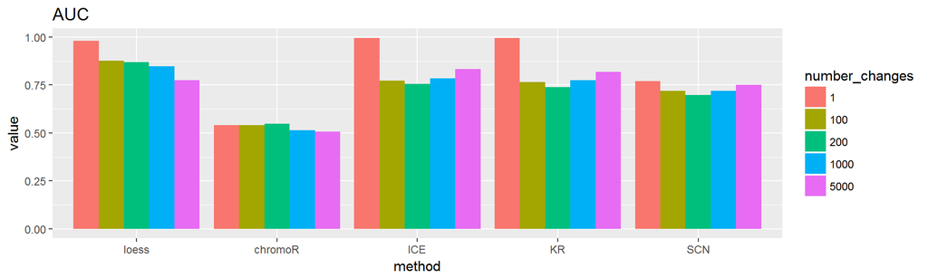

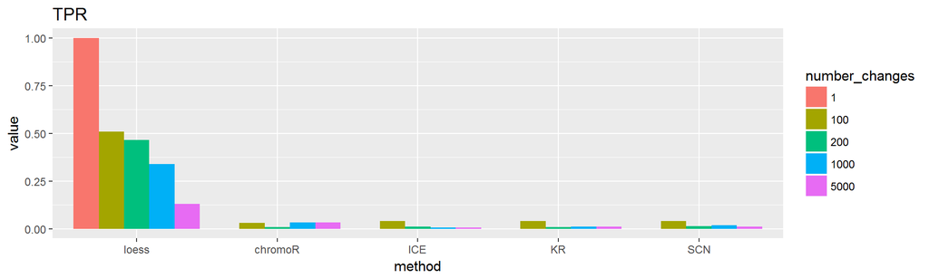

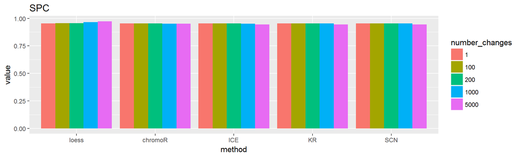

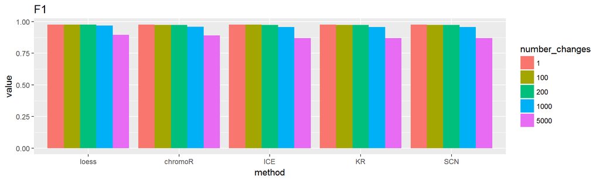

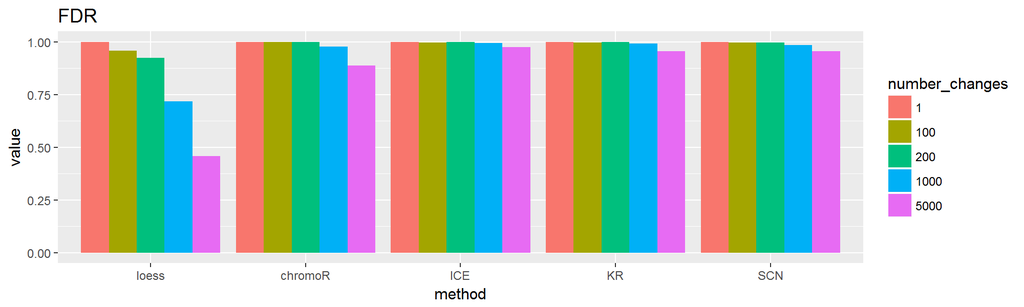

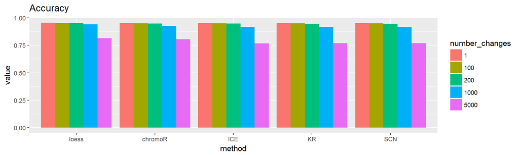

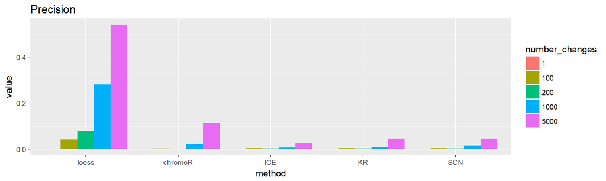

### Summary

`loess` was able to detect a single true change added at a 1.5 fold change. `loess` also detected the most changes that were added for all levels changes made compared to the other methods. `loess` again had the lowest numbers of false negatives compared to the other methods. Interestingly, `ChromoR` seemed to detect more differences when a large number of changes were made (1000 and 5000) compared to `KR`, `SCN`, and `ICE`.